# SIR Simulation

```r
library(graphics)
library(SIRSimulation)
```

## Getting started

To get started with this package, you must first create a matrix that you can input into the simulation. You can use one of the methods to create a matrix in the package, or you can input a completely custom matrix. It is required that the input is a matrix data type, however, the size of the matrix does not matter.

You can create a matrix with a given chance of each cell starting as infected using the function.

```r
# Matrix with 25% chance of each cell starting infected
x <- create_matrix(5,5,0.25)
```

Similarly, you can use other designs such as starting the corners or very center cell as infected.

```r
# corners infected matrix
corners <- create_crnr_matrix(5,5)

# Center infected matrix
center <- create_cntr_matrix(15,15)
```

Or you can create your own custom matrix to use an your input.

## Running a simulation

To run a basic single simulation use the following function.

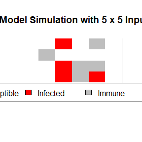

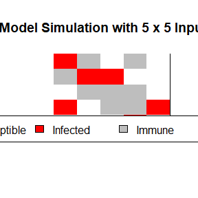

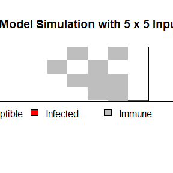

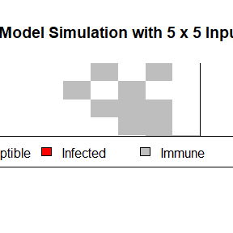

```
#> $steps
#> [1] 4
#>
#> $prob_infect
#> [1] 0.25
#>
#> $inf_prop
#> [1] 0.44
#>
#> $imm_prob
#> [1] 0.5
#>
#> $final_matrix
#>      [,1] [,2] [,3] [,4] [,5]
#> [1,]    0    2    0    2    0
#> [2,]    2    0    2    0    0
#> [3,]    0    2    2    2    0
#> [4,]    0    0    2    2    0
#> [5,]    0    0    0    2    2
```

```r
# Run a basic simulation on matrix x
# Set probability of infection to 0.25
# Use default values auto_immunity FALSE and allow_death FALSE
# Since auto_immunity is FALSE, this will use the default immunity probability value of 0.5
simulate_sir(0.25,x)
```

However, there are some additional arguments we can add to the simulation call to increase the complexity of the simulation.

You can specify a specific probability of immunity by using the following arguments.

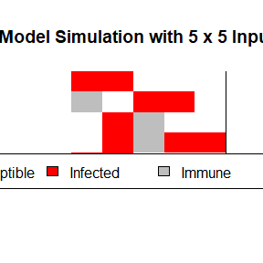

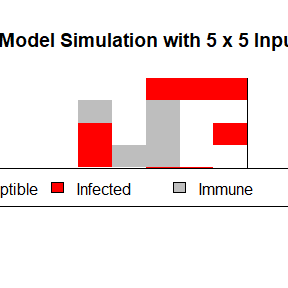

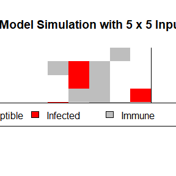

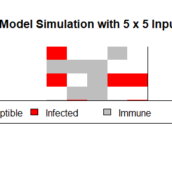

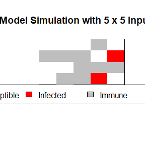

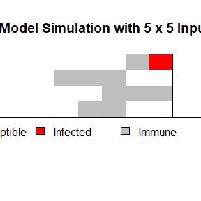

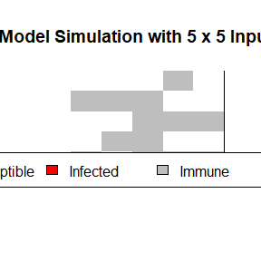

```
#> $steps
#> [1] 7
#>
#> $prob_infect
#> [1] 0.25
#>
#> $inf_prop
#> [1] 0.52
#>
#> $imm_prob
#> [1] 0.34
#>
#> $final_matrix
#>      [,1] [,2] [,3] [,4] [,5]
#> [1,]    0    0    0    2    0
#> [2,]    2    2    2    0    0
#> [3,]    0    0    2    2    2
#> [4,]    0    2    2    0    0
#> [5,]    2    0    2    2    2
```

```r
# Run a basic simulation on matrix x
# Set probability of infection to 0.25
# Use default values auto_immunity FALSE and allow_death FALSE
# Set value for immunity probability to 0.34
simulate_sir(0.25,x,FALSE,0.34)
```

We can enable the auto_immunity parameter so that every cell that gets infected automatically gains immunity.

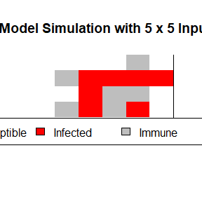

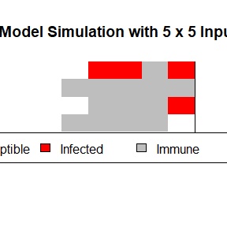

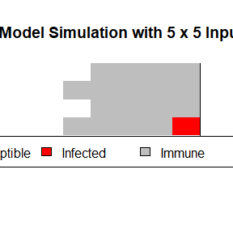

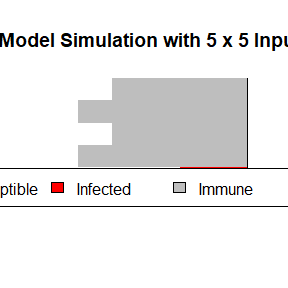

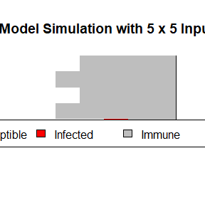

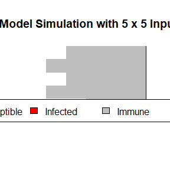

```
#> $steps
#> [1] 6
#>
#> $prob_infect
#> [1] 0.25
#>
#> $inf_prop
#> [1] 0.84
#>
#> $final_matrix
#>      [,1] [,2] [,3] [,4] [,5]
#> [1,]    0    2    2    2    2
#> [2,]    2    2    2    2    2
#> [3,]    0    2    2    2    2
#> [4,]    2    2    2    2    2
#> [5,]    0    0    2    2    2
```

```r
# Run a basic simulation on matrix x
# Set probability of infection to 0.25
# Set auto_immunity to TRUE and use default value of allow_death FALSE
simulate_sir(0.25,x,TRUE)
```

Additionally, we can enable the allow_death parameter to enable cells to become Immune or Deceased after infection.

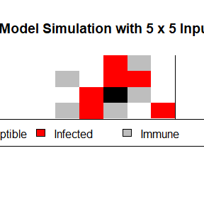

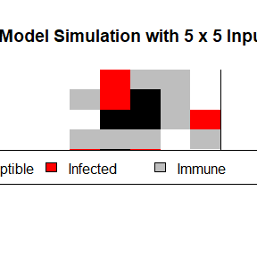

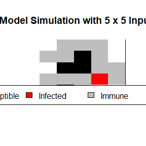

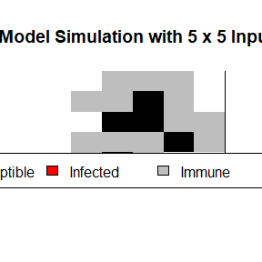

```
#> $steps
#> [1] 4
#>
#> $prob_infect
#> [1] 0.25
#>
#> $inf_prop
#> [1] 0.56
#>
#> $fat_prob
#> [1] 0.19
#>
#> $final_matrix
#>      [,1] [,2] [,3] [,4] [,5]
#> [1,]    0    2    2    2    0
#> [2,]    2    2    3    2    0
#> [3,]    0    3    3    2    2
#> [4,]    2    2    2    3    2
#> [5,]    2    3    2    0    0
```

```r
# Run a basic simulation on matrix x
# Set probability of infection to 0.25
# Set auto_immunity to TRUE and immunity probability to 0.0
# Set allow_death to TRUE and fatality probability to 0.19
simulate_sir(0.25,x,TRUE,0.0,TRUE,0.19)
```

Lastly, we can disable the auto_immunity parameter and enable the allow_death parameter to enable cells to become Susceptible, Immune, or Deceased after infection.

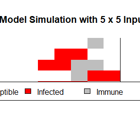

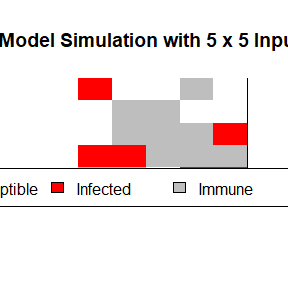

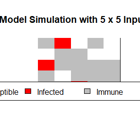

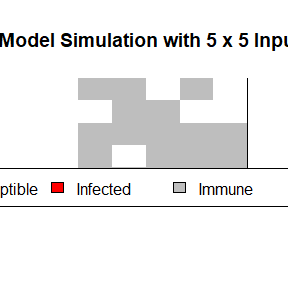

```
#> $steps
#> [1] 4
#>
#> $prob_infect
#> [1] 0.25
#>
#> $inf_prop
#> [1] 0.76
#>
#> $imm_prob
#> [1] 0.35
#>
#> $fat_prob
#> [1] 0.12
#>
#> $final_matrix
#>      [,1] [,2] [,3] [,4] [,5]
#> [1,]    2    2    0    2    0
#> [2,]    0    2    2    0    0
#> [3,]    2    2    2    2    2
#> [4,]    2    0    2    2    2
#> [5,]    2    2    2    2    2
```

```r
# Run a basic simulation on matrix x
# Set probability of infection to 0.25
# Set auto_immunity to FALSE and immunity probability to 0.35
# Set allow_death to TRUE and fatality probability to 0.12
simulate_sir(0.25,x,FALSE,0.35,TRUE,0.12)
```

## Simulating models over a sequence of infection probabilities

You can also run any of the above models over a sequence of different infection probabilities to compare results.

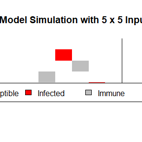

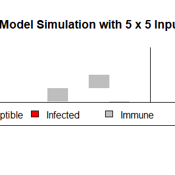

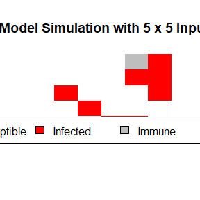

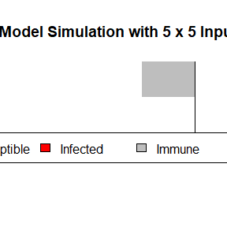

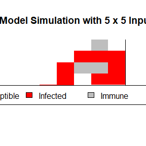

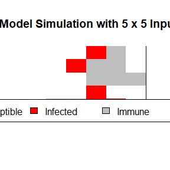

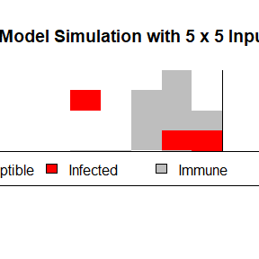

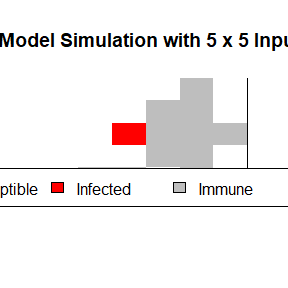

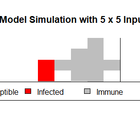

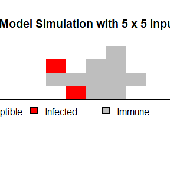

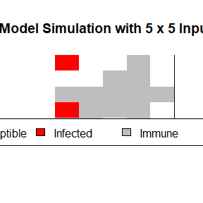

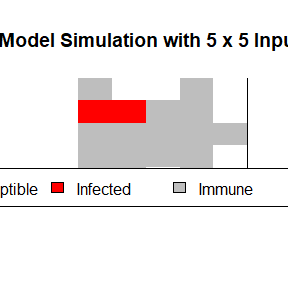

[34 more figures not shown]

```
#>   prob_infection total_steps infected_prop immunity_prob
#> 1            0.1           2          0.12           0.5
#> 2            0.2           2          0.16           0.5
#> 3            0.3           9          0.64           0.5
#> 4            0.4           5          0.52           0.5
#> 5            0.5           6          0.80           0.5
#> 6            0.6           4          0.72           0.5
#> 7            0.7           5          0.92           0.5
#> 8            0.8           7          0.88           0.5
#> 9            0.9           6          0.92           0.5
```

```r
# Run the sequence of infection probabilities using the basic simulation on matrix x from above
# Set step in sequence to 0.1
simulate_inf_seq(x,0.1)
```

You can modify the parameters of this function the same as the simulate_sir() function to modify the simulation settings.

## Simulate many model runs

You can run any of the above models a specified number times to get the average statistics.

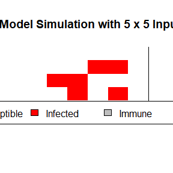

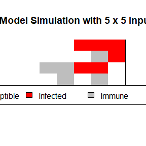

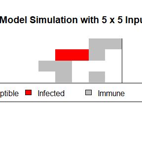

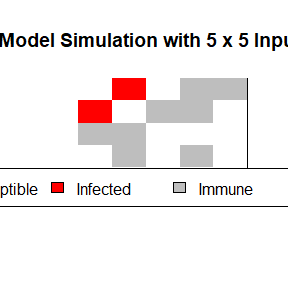

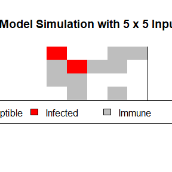

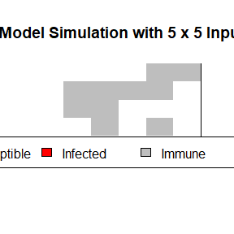

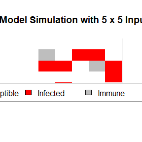

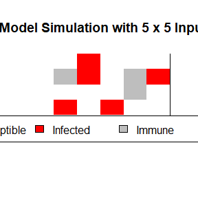

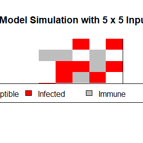

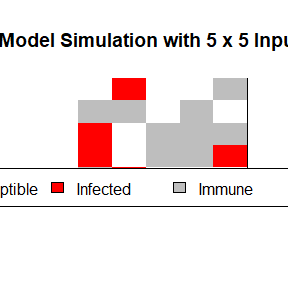

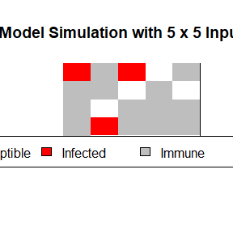

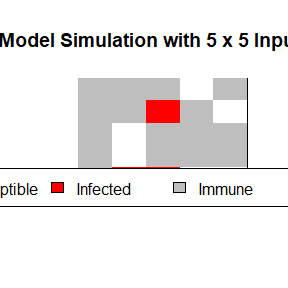

[1 more figures not shown]

```
#>   total_runs avg_steps avg_prop_infected
#> 1          2       6.5              0.56
```

```r
# Run a basic simulation on matrix x many times and report average statistics
# Set probability of infection to 0.25
# Set number of runs to 2
simulate_many_runs(0.25,x,2)
```

You can modify the parameters of this function the same as the simulate_sir() function to modify the simulation settings.